# Affymetrix data analysis

Ignasi Jarne Sanz

19/4/2022

Working directory and packages

```r
setwd("C:/Users/User/Desktop/omic/")
```

```r
library(dplyr)
library(knitr)
library(kableExtra)
library(oligo)
library(Biobase)
library(arrayQualityMetrics)
library(ggplot2)
library(ggrepel)
library(Rcpp)
library(genefilter)
library(clariomdhumantranscriptcluster.db)
library(limma)
library(org.Hs.eg.db)
library(grDevices)
library(ggnewscale)
library(gplots)
library(GO.db)
library(GOstats)
library(reactome.db)
library(ReactomePA)
```

## Characterization and sample selection.

#### Aleatory sample selection

Out of 47 total samples, we will collect 15 (5 per group). This 47 samples are stored in a subdirectory called “copia”.

```r
noms_raw <- list.files("./copia/")
numbers <- seq(1,47, by=1)
fenotip <- rep(c("Symptomatic","Asymptomatic","Healthy controls"),
               times=c(11,18,18))

Muestras <- data.frame(numbers,noms_raw,fenotip)
head(Muestras)
```

```
##   numbers          noms_raw     fenotip
## 1       1 GSM5374839_S1.CEL Symptomatic
## 2       2 GSM5374840_S2.CEL Symptomatic
## 3       3 GSM5374841_S3.CEL Symptomatic
## 4       4 GSM5374842_S4.CEL Symptomatic
## 5       5 GSM5374843_S5.CEL Symptomatic
## 6       6 GSM5374844_S6.CEL Symptomatic
```

```r
set.seed(2907)
Sym <- sample(1:11, 5, replace = F);sort(Sym)
```

```
## [1] 1 2 5 7 8
```

```r
Asym <- sample(12:29, 5, replace = F);sort(Asym)
```

```
## [1] 18 20 21 23 27
```

```r
Heal <- sample(30:47, 5, replace = F);sort(Heal)
```

```
## [1] 30 32 38 42 43
```

```r
print(Muestras[c(Sym,Asym,Heal),])
```

```
##    numbers           noms_raw          fenotip
## 1        1  GSM5374839_S1.CEL      Symptomatic
## 8        8  GSM5374846_S8.CEL      Symptomatic
## 2        2  GSM5374840_S2.CEL      Symptomatic
## 7        7  GSM5374845_S7.CEL      Symptomatic
## 5        5  GSM5374843_S5.CEL      Symptomatic
## 18      18 GSM5374856_S18.CEL     Asymptomatic
## 23      23 GSM5374861_S23.CEL     Asymptomatic
## 20      20 GSM5374858_S20.CEL     Asymptomatic
## 21      21 GSM5374859_S21.CEL     Asymptomatic
## 27      27 GSM5374865_S27.CEL     Asymptomatic
## 30      30 GSM5374868_S30.CEL Healthy controls
## 43      43 GSM5374881_S43.CEL Healthy controls
## 38      38 GSM5374876_S38.CEL Healthy controls
## 42      42 GSM5374880_S42.CEL Healthy controls
## 32      32 GSM5374870_S32.CEL Healthy controls
```

We create a target tile based on the selected samples, this target file is stored in a subdirectory called “dades”.

We list the selected files, that we will have stored a subdirectory called “dades”.

```r
celFiles <- list.celfiles("./dades", full.names = T)
my.targets <- read.AnnotatedDataFrame(file.path("./dades","targets.csv"),
                                      header = T, row.names = 1,
                                      sep = ";")
rawData <- read.celfiles(celFiles, phenoData = my.targets)
```

```
## Reading in : ./dades/GSM5374839_S1.CEL
## Reading in : ./dades/GSM5374840_S2.CEL
## Reading in : ./dades/GSM5374843_S5.CEL
## Reading in : ./dades/GSM5374845_S7.CEL
## Reading in : ./dades/GSM5374846_S8.CEL
## Reading in : ./dades/GSM5374856_S18.CEL
## Reading in : ./dades/GSM5374858_S20.CEL
## Reading in : ./dades/GSM5374859_S21.CEL
## Reading in : ./dades/GSM5374861_S23.CEL
## Reading in : ./dades/GSM5374865_S27.CEL
## Reading in : ./dades/GSM5374868_S30.CEL
## Reading in : ./dades/GSM5374870_S32.CEL
## Reading in : ./dades/GSM5374876_S38.CEL
## Reading in : ./dades/GSM5374880_S42.CEL
## Reading in : ./dades/GSM5374881_S43.CEL
```

Change the data names for readable names.

```r
head(rawData@assayData[["exprs"]])
```

```
##   GSM5374839_S1.CEL GSM5374840_S2.CEL GSM5374843_S5.CEL GSM5374845_S7.CEL
## 1              4813              5134              4813              1080
## 2                93                90                93                41
## 3              4813              4925              4813               925
## 4                87                57                87                35
## 5                63                49                63                45
## 6                49                55                49                43
##   GSM5374846_S8.CEL GSM5374856_S18.CEL GSM5374858_S20.CEL GSM5374859_S21.CEL
## 1              2053               2067               2349               9333
## 2                52                 58                 62                174
## 3              1936               2064               2138               8622
## 4                35                 40                 47                143
## 5                48                 53                 59                 76
## 6                39                 41                 44                 66
##   GSM5374861_S23.CEL GSM5374865_S27.CEL GSM5374868_S30.CEL GSM5374870_S32.CEL
## 1               9791               7976               7837               2451
## 2                172                229                168                 50
## 3               9869               7522               8853               2584
## 4                205                127                191                 52
## 5                125                 59                 72                 93
## 6                101                 55                 83                 56
##   GSM5374876_S38.CEL GSM5374880_S42.CEL GSM5374881_S43.CEL
## 1               4097               8131               7968
## 2                 52                105                179
## 3               3855               7044               7446
## 4                 42                 59                183
## 5                 56                 91                 41
## 6                 56                 85                 71
```

```r
colnames(rawData) <-rownames(pData(rawData)) <- my.targets@data$ShortName # Changing the name
head(rawData@assayData[["exprs"]]) # Checking the names
```

```
##   Symp1 Symp2 Symp3 Symp4 Symp5 Asymp1 Asymp2 Asymp3 Asymp4 Asymp5 Health1
## 1  4813  5134  4813  1080  2053   2067   2349   9333   9791   7976    7837
## 2    93    90    93    41    52     58     62    174    172    229     168
## 3  4813  4925  4813   925  1936   2064   2138   8622   9869   7522    8853
## 4    87    57    87    35    35     40     47    143    205    127     191
## 5    63    49    63    45    48     53     59     76    125     59      72
## 6    49    55    49    43    39     41     44     66    101     55      83
##   Health2 Health3 Health4 Health5
## 1    2451    4097    8131    7968
## 2      50      52     105     179
## 3    2584    3855    7044    7446
## 4      52      42      59     183
## 5      93      56      91      41
## 6      56      56      85      71
```

## Quality control and data exploration of the raw expression data

Applying “arrayQualitMetrics” on the raw data, this creates a .html file with quality metrics regardin the loaded data.

```r
arrayQualityMetrics(rawData,
                    outdir =file.path("./resultats", "QC_Raw"), force = T)
```

```
## The report will be written into directory './resultats/QC_Raw'.
```

Some exploratory analysis on our expression data

### Density plot

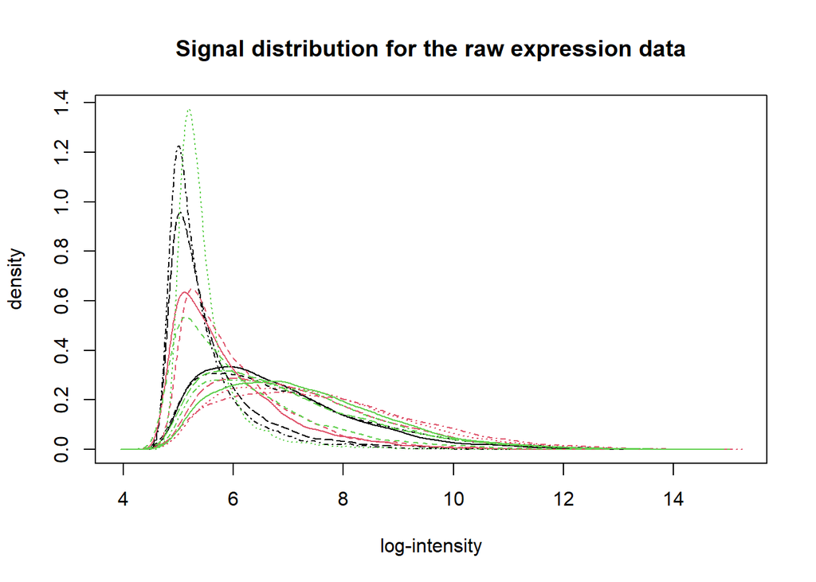

```r
colors <- rep(c(1,2,3),times=c(5,5,5))
hist(rawData, main="Signal distribution for the raw expression data", col=colors)
```

### Boxplots

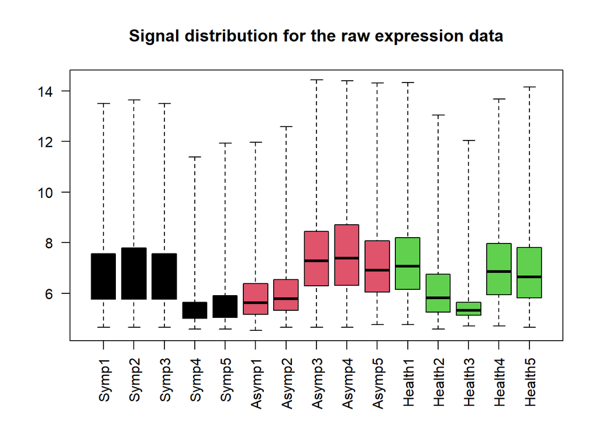

```r
boxplot(rawData, main="Signal distribution for the raw expression data", col=colors, las=2)
```

Las gáficas generadas en este apartado nos muestran que los datos no están normalizados.

### PCA

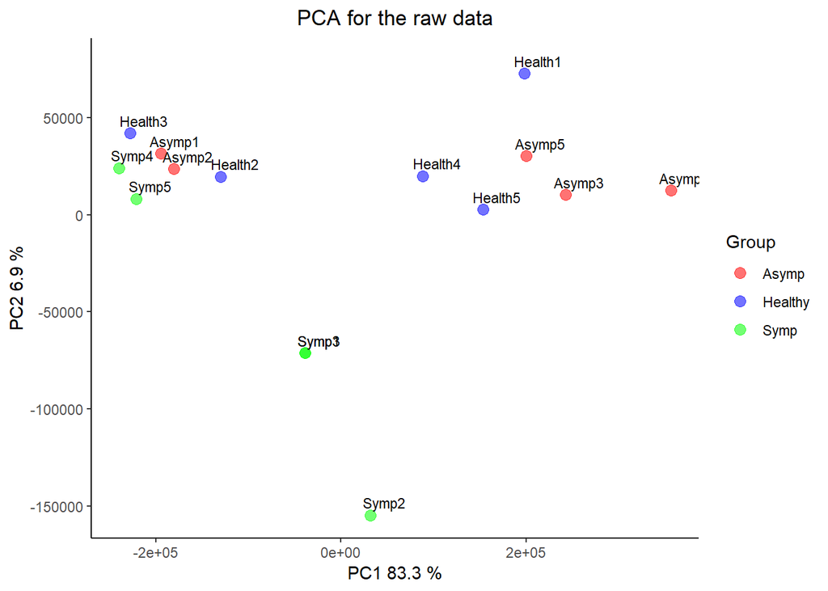

```r
# función
plotPCA3 <- function (datos, labels, factor, title, scale,colores, size = 1.5, glineas = 0.25) {
  data <- prcomp(t(datos),scale=scale)
  # plot adjustments
  dataDf <- data.frame(data$x)
  Group <- factor
  loads <- round(data$sdev^2/sum(data$sdev^2)*100,1)
  # main plot
  p1 <- ggplot(dataDf,aes(x=PC1, y=PC2)) +
    theme_classic() +
    geom_point(aes(color = Group), alpha = 0.55, size = 3) +
    coord_cartesian(xlim = c(min(data$x[,1])-5,max(data$x[,1])+5)) +
    scale_fill_discrete(name = "Group")
  p1 + geom_text(aes(y = PC2 +6500, x=PC1+15000,
                     label = labels), size=size)+
    labs(x = c(paste("PC1",loads[1],"%")),y=c(paste("PC2",loads[2],"%"))) +
    ggtitle("PCA for the raw data")+
    theme(plot.title = element_text(hjust = 0.5)) +
    scale_color_manual(values=colores)
}

plotPCA3(exprs(rawData), labels=targets$ShortName, factor = targets$Grup,
        title = "Raw Data", scale=FALSE, size=3,
        colores = c("red","blue","green"))
```

## Expression data RMA transformation

```r
normData <- rma(rawData)
```

```
## Background correcting
## Normalizing
## Calculating Expression
```

## Quality control on the RMA transformed data

```r
arrayQualityMetrics(normData,
                    outdir =file.path("./resultats", "QC_Norm"), force = T)
```

```
## The report will be written into directory './resultats/QC_Norm'.
```

### Density plot

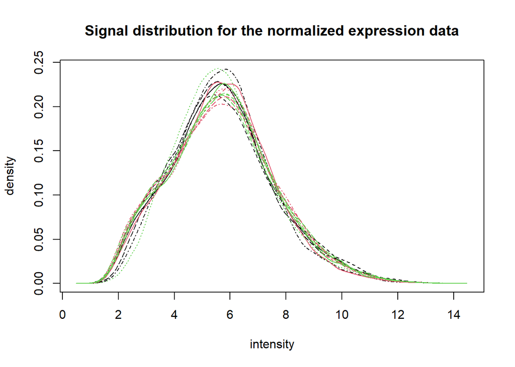

```r
colors <- rep(c(1,2,3),times=c(5,5,5))
hist(normData, main="Signal distribution for the normalized expression data", col=colors)
```

### Boxplots

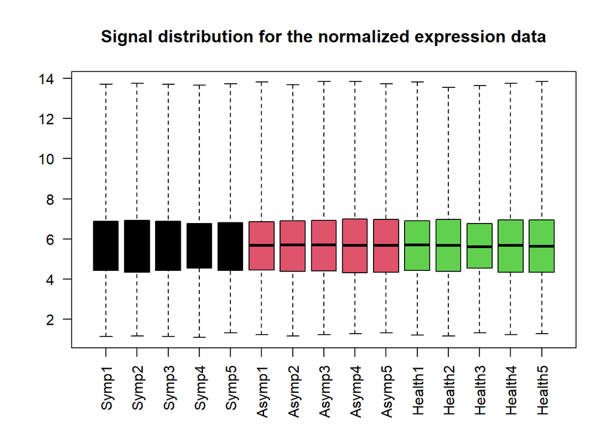

```r
boxplot(normData, main="Signal distribution for the normalized expression data", col=colors, las=2)
```

### PCA

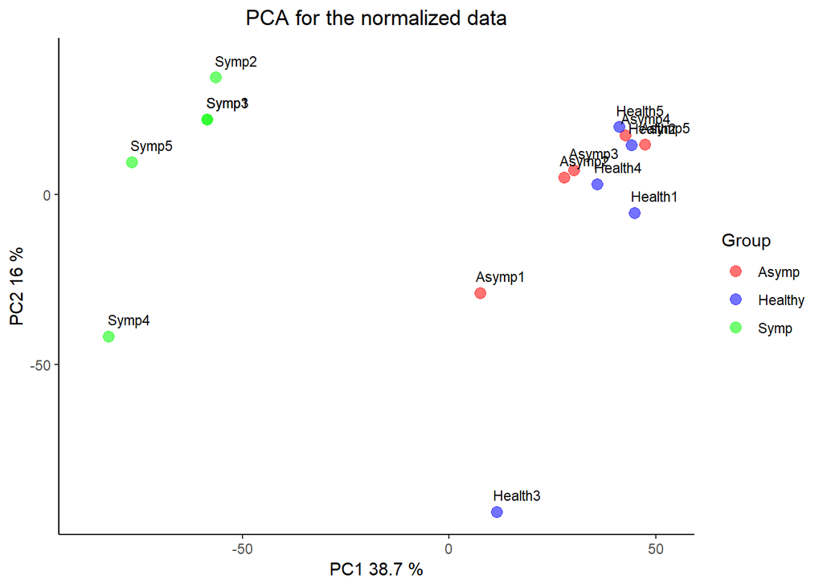

```r
# función
plotPCA3 <- function (datos, labels, factor, title, scale,colores, size = 1.5, glineas = 0.25) {
  data <- prcomp(t(datos),scale=scale)
  # plot adjustments
  dataDf <- data.frame(data$x)
  Group <- factor
  loads <- round(data$sdev^2/sum(data$sdev^2)*100,1)
  # main plot
  p1 <- ggplot(dataDf,aes(x=PC1, y=PC2)) +
    theme_classic() +
    geom_point(aes(color = Group), alpha = 0.55, size = 3) +
    coord_cartesian(xlim = c(min(data$x[,1])-5,max(data$x[,1])+5)) +
    scale_fill_discrete(name
                        = "Group")
  # avoiding labels superposition
  p1 + geom_text(aes(y = PC2+5, x=PC1+5,
                     label = labels), size=size)+
    labs(x = c(paste("PC1",loads[1],"%")),y=c(paste("PC2",loads[2],"%"))) +
    ggtitle("PCA for the normalized data")+
    theme(plot.title = element_text(hjust = 0.5)) +
    scale_color_manual(values=colores)
}

plotPCA3(exprs(normData), labels=targets$ShortName, factor = targets$Grup,
        title = "Norm", scale=FALSE, size=3,
        colores = c("red","blue","green"))
```

## Non specific gene filtering

We will filter the 25% of genes that show the greatest variation between groups. This step is not mandatory.

```r
annotation(normData) <- "clariomdhumantranscriptcluster.db"
filtered <- nsFilter(normData,
                     require.entrez = T, remove.dupEntrez = T,
                     var.filter = T, var.func = IQR, var.cutoff = 0.75,
                     filterByQuantile = T, feature.exclude = "^AFFX")

print(filtered$filter.log)
```

```
## $numDupsRemoved
## [1] 88
##
## $numLowVar
## [1] 13858
##
## $numRemoved.ENTREZID
## [1] 8624
```

```r
filtered_data <- filtered$eset
filteredData <- exprs(filtered_data)
colnames(filteredData) <- pData(filtered$eset)$ShortName
```

## DEGs identification

Design matrix

```r
grup <- pData(filtered$eset)$Grup
lev <- factor(grup, levels = unique(grup))
design <- model.matrix(~0+lev)
colnames(design) <- levels(lev)
rownames(design) <- targets$ShortName
print(design)
```

```
##         Symp Asymp Healthy
## Symp1      1     0       0
## Symp2      1     0       0
## Symp3      1     0       0
## Symp4      1     0       0
## Symp5      1     0       0
## Asymp1     0     1       0
## Asymp2     0     1       0
## Asymp3     0     1       0
## Asymp4     0     1       0
## Asymp5     0     1       0
## Health1    0     0       1
## Health2    0     0       1
## Health3    0     0       1
## Health4    0     0       1
## Health5    0     0       1
## attr(,"assign")
## [1] 1 1 1
## attr(,"contrasts")
## attr(,"contrasts")$lev
## [1] "contr.treatment"
```

Contrast matrix

```r
contrast_mat <- makeContrasts(SympvsAsymp = Symp-Asymp,
                              SympvsHealth = Symp-Healthy,
                              AsympvsHealth = Asymp-Healthy,
                              levels = design)
print(contrast_mat)
```

```
##          Contrasts
## Levels    SympvsAsymp SympvsHealth AsympvsHealth
##   Symp              1            1             0
##   Asymp            -1            0             1
##   Healthy           0           -1            -1
```

Linear model generation

```r
fit <- lmFit(filteredData, design)
fiit.main <- contrasts.fit(fit, contrast_mat)
fiit.main <- eBayes(fiit.main)
```

Results extraction

```r
TT_Sym_vs_Asym <- topTable(fiit.main, number = nrow(fiit.main), coef = "SympvsAsymp",adjust.method = "fdr")
TT_Sym_vs_Health <- topTable(fiit.main, number = nrow(fiit.main), coef = "SympvsHealth",adjust.method = "fdr")
TT_Asymp_vs_Health <- topTable(fiit.main, number = nrow(fiit.main), coef = "AsympvsHealth",adjust.method = "fdr")
```

Some numbers

```r
DEGs1 <- nrow(topTable(fiit.main, number = nrow(fiit.main), coef = "SympvsAsymp",adjust.method = "fdr",
                       lfc = 2, p.value = 0.05));DEGs1
```

```
## [1] 220
```

```r
DEGs2 <- nrow(topTable(fiit.main, number = nrow(fiit.main), coef = "SympvsHealth",adjust.method = "fdr",
                       lfc = 2, p.value = 0.05));DEGs2
```

```
## [1] 253
```

```r
DEGs3 <- nrow(topTable(fiit.main, number = nrow(fiit.main), coef = "AsympvsHealth",adjust.method = "fdr",
                       lfc = 2, p.value = 0.05));DEGs3
```

```
## [1] 16
```

## Results annotations

```r
keytypes(clariomdhumantranscriptcluster.db)
```

```
##  [1] "ACCNUM"       "ALIAS"        "ENSEMBL"      "ENSEMBLPROT"  "ENSEMBLTRANS"
##  [6] "ENTREZID"     "ENZYME"       "EVIDENCE"     "EVIDENCEALL"  "GENENAME"
## [11] "GENETYPE"     "GO"           "GOALL"        "IPI"          "MAP"
## [16] "OMIM"         "ONTOLOGY"     "ONTOLOGYALL"  "PATH"         "PFAM"
## [21] "PMID"         "PROBEID"      "PROSITE"      "REFSEQ"       "SYMBOL"
## [26] "UCSCKG"       "UNIPROT"
```

We will extract the following information:

- Symbol
- ENTREZID
- Gene name

```r
annotations <- AnnotationDbi::select(clariomdhumantranscriptcluster.db, keys = rownames(filteredData),columns = c("SYMBOL","GENENAME","ENTREZID"))
head(annotations)
```

```
##             PROBEID    SYMBOL
## 1 TC1400010768.hg.1      MED6
## 2 TC1100011614.hg.1     KCNE3
## 3 TC0200009806.hg.1      TANK
## 4 TC0700011550.hg.1   POM121C
## 5 TC0700013163.hg.1 HTR5A-AS1
## 6 TC0600012968.hg.1  TRAPPC3L
##                                                           GENENAME  ENTREZID
## 1                                       mediator complex subunit 6     10001
## 2 potassium voltage-gated channel subfamily E regulatory subunit 3     10008
## 3                     TRAF family member associated NFKB activator     10010
## 4                               POM121 transmembrane nucleoporin C 100101267
## 5                                            HTR5A antisense RNA 1 100128264
## 6                  trafficking protein particle complex subunit 3L 100128327
```

Getting the extracted annotation with our results.

```r
TT_Sym_vs_Asym <- TT_Sym_vs_Asym %>%
  mutate(PROBEID=rownames(TT_Sym_vs_Asym)) %>%
  left_join(annotations) %>%
  arrange(P.Value)
TT_Sym_vs_Asym <- TT_Sym_vs_Asym[,c(7,8,9,10,
                                    1,2,3,4,5,6)]


TT_Sym_vs_Health <- TT_Sym_vs_Health %>%
  mutate(PROBEID=rownames(TT_Sym_vs_Health)) %>%
  left_join(annotations) %>%
  arrange(P.Value)
TT_Sym_vs_Health <- TT_Sym_vs_Health[,c(7,8,9,10,
                                    1,2,3,4,5,6)]



TT_Asymp_vs_Health <- TT_Asymp_vs_Health %>%
  mutate(PROBEID=rownames(TT_Asymp_vs_Health)) %>%
  left_join(annotations) %>%
  arrange(P.Value)
TT_Asymp_vs_Health <- TT_Asymp_vs_Health[,c(7,8,9,10,
                                    1,2,3,4,5,6)]

head(TT_Sym_vs_Asym)
```

```
##             PROBEID  SYMBOL                       GENENAME ENTREZID    logFC
## 1 TC1500010184.hg.1  BCL2A1        BCL2 related protein A1      597 4.562781
## 2 TC0100011453.hg.1    G0S2                 G0/G1 switch 2    50486 4.107885
## 3 TC0800010607.hg.1    ASPH     aspartate beta-hydroxylase      444 3.337937
## 4 TC1400008940.hg.1  NFKBIA           NFKB inhibitor alpha     4792 3.422181
## 5 TC0600009597.hg.1 TNFAIP3    TNF alpha induced protein 3     7128 3.301291
## 6 TC0400007836.hg.1   CXCL8 C-X-C motif chemokine ligand 8     3576 5.180687
##    AveExpr        t      P.Value    adj.P.Val        B
## 1 8.457254 15.99546 1.246172e-13 5.756067e-10 21.14698
## 2 7.271086 14.24764 1.292264e-12 2.346162e-09 18.93606
## 3 9.675833 13.93417 2.014942e-12 2.346162e-09 18.51176
## 4 9.887063 13.92836 2.031749e-12 2.346162e-09 18.50381
## 5 9.515669 13.42971 4.189530e-12 2.983065e-09 17.80977
## 6 7.107279 13.39287 4.423327e-12 2.983065e-09 17.75756
```

## Comparing results.

```r
gene_sym <- select(clariomdhumantranscriptcluster.db, rownames(fiit.main), c("SYMBOL"))
gene_sym <- gene_sym$SYMBOL
```

### Volcano plots

#### Contrast 1

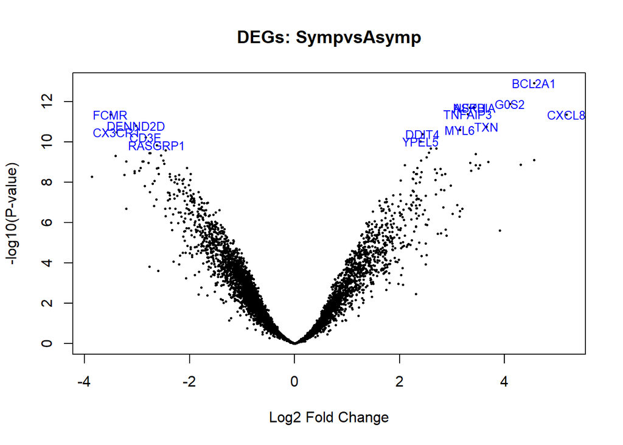

```r
volcanoplot(fiit.main, coef = 1, highlight = 15, names = gene_sym,main=paste("DEGs:", colnames(contrast_mat)[1]))
```

#### Contrast 2

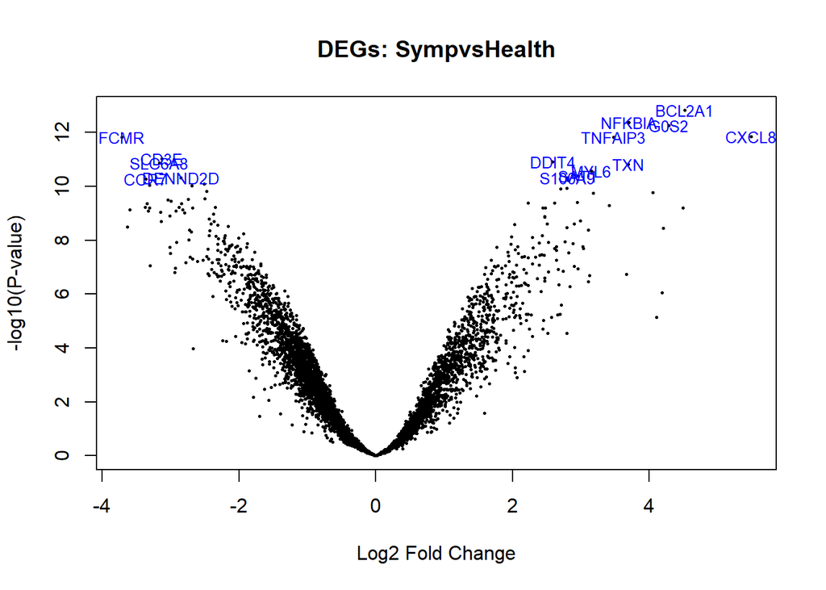

```r
volcanoplot(fiit.main, coef = 2, highlight = 15, names = gene_sym,main=paste("DEGs:", colnames(contrast_mat)[2]))
```

#### Contrast 3

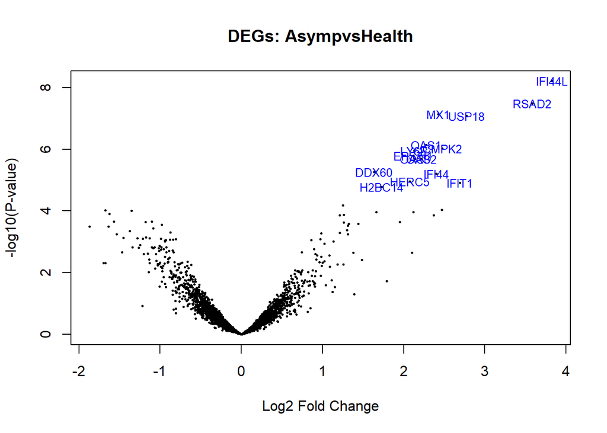

```r
volcanoplot(fiit.main, coef = 3, highlight = 15, names = gene_sym,main=paste("DEGs:", colnames(contrast_mat)[3]))
```

### Comparing results

#### Venn Diagram

Preparing the data

```r
comparing <- decideTests(fiit.main, method = "separate", adjust.method = "fdr",
                         p.value = 0.05, lfc = 2)
comparing_rows <- apply(abs(comparing),1,sum)
comparing_sel <- comparing[comparing_rows!=0,]
print(summary(comparing))
```

```
##        SympvsAsymp SympvsHealth AsympvsHealth
## Down            98          129             0
## NotSig        4399         4366          4603
## Up             122          124            16
```

Plotting

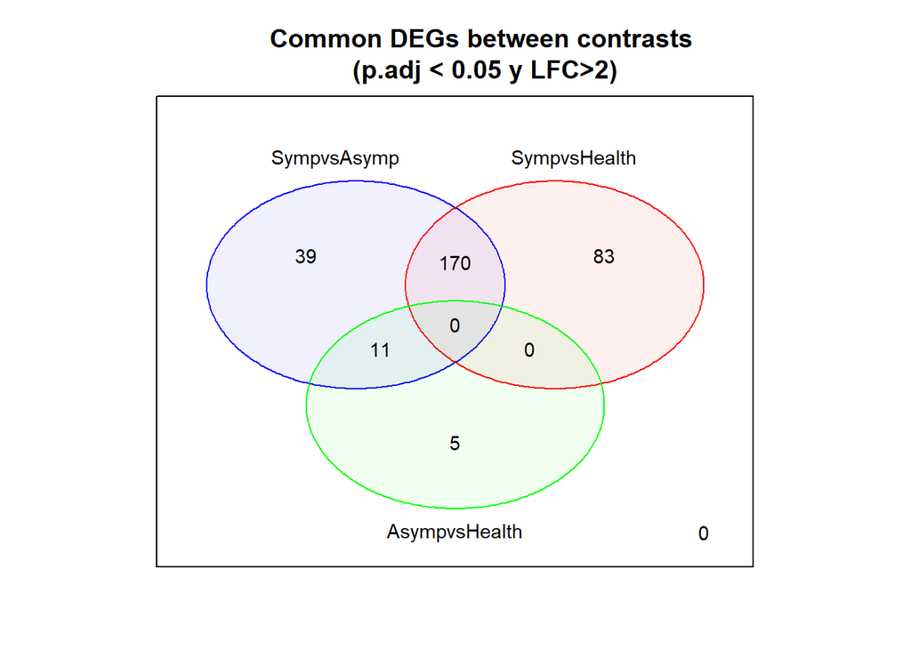

```r
vennDiagram(comparing_sel[,1:3], cex = 0.9,
            circle.col = c("blue","red","green"))
title("Common DEGs between contrasts\n (p.adj < 0.05 y LFC>2)")
```

#### Heatmap

Preparing the data

```r
probes_heat <- rownames(comparing_sel)
heat_data <- exprs(filtered_data)[rownames(exprs(filtered_data)) %in% probes_heat,]
heat_symbols <- select(clariomdhumantranscriptcluster.db, rownames(heat_data), c("SYMBOL"))
heat_symbols <- heat_symbols$SYMBOL
rownames(heat_data) <- heat_symbols
head(heat_data)
```

```
##                   Symp1     Symp2    Symp3    Symp4     Symp5   Asymp1   Asymp2
## ERVK13-1       4.581948  4.646649 4.581948 4.661575  4.040990 5.689494 6.098580
## RPL36A-HNRNPH2 7.095894  7.946345 7.095894 7.143064  7.561641 4.552553 5.182294
## TSPAN5         7.006021  6.440737 7.006021 6.128309  6.282329 7.381128 7.143361
## RASGRP1        6.155803  5.745198 6.155803 5.580135  5.344597 7.975628 8.439767
## KLRG1          5.742416  5.717588 5.744100 4.501760  4.548198 7.473230 9.032571
## TRIB1          9.823364 10.962948 9.823364 9.780350 10.804040 8.123439 7.957524
##                  Asymp3   Asymp4   Asymp5  Health1  Health2  Health3  Health4
## ERVK13-1       6.252849 6.454490 6.624775 6.699811 7.917594 5.853072 6.636106
## RPL36A-HNRNPH2 4.706167 5.634288 5.225018 4.979939 5.190790 6.744431 5.007123
## TSPAN5         6.651935 8.558948 8.881186 9.949111 9.449638 9.070503 9.229970
## RASGRP1        8.400036 8.710073 8.572002 8.664760 8.427445 8.250978 8.884584
## KLRG1          8.319856 8.560525 8.098238 8.469039 8.023210 7.982178 9.098820
## TRIB1          7.859877 7.506188 7.760775 7.589935 7.597699 7.721823 7.569137
##                 Health5
## ERVK13-1       6.657475
## RPL36A-HNRNPH2 4.803802
## TSPAN5         9.038743
## RASGRP1        8.196054
## KLRG1          8.374055
## TRIB1          8.179212
```

Plotting

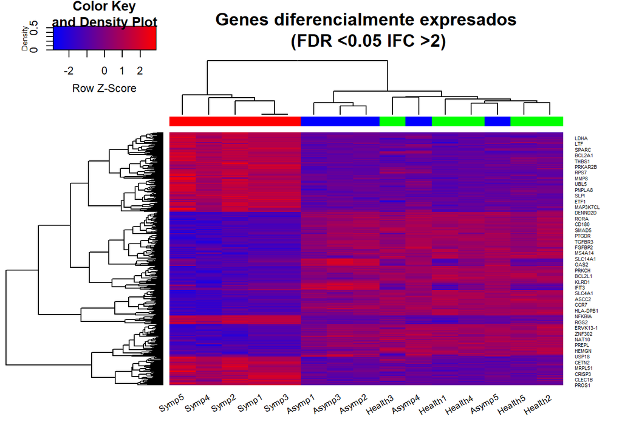

```r
heatmap.2(heat_data,
          Rowv = T,
          Colv = T,
          dendrogram = "both",
          main = "Genes diferencialmente expresados\n (FDR <0.05 lFC >2)",
          scale = "row",
          col = colorRampPalette(c("blue","red"))(n=300),
          sepcolor = "white",
          sepwidth = c(0.05,0.05),
          cexRow = 0.5,
          cexCol = 0.9,
          key = T,
          keysize = 1.5,
          density.info = "density",
          ColSideColors = c(rep("red",5),rep("blue",5),rep("green",5)),
          tracecol = NULL,
          srtCol = 30)
```

## Biological significance analysis

Preparing the data

```r
tables_to_use <- list(Symp_vs_Asymp = TT_Sym_vs_Asym,
                      Symp_vs_Healthy = TT_Sym_vs_Health,
                      Asym_vs_Healty = TT_Asymp_vs_Health)

list_of_selected <- list()
for (i in 1:length(tables_to_use)){
  topTab <- tables_to_use[[i]]
  genes_to_use <- topTab["adj.P.Val"]<0.15
  IDs_to_use <- (topTab$PROBEID)[genes_to_use]
  EntrezID <- select(clariomdhumantranscriptcluster.db, IDs_to_use, c("ENTREZID"))
  EntrezID <- EntrezID$ENTREZID
  list_of_selected[[i]] <- EntrezID
  names(list_of_selected)[i] <- names(tables_to_use)[i]
}
sapply(list_of_selected, length)
```

```
##   Symp_vs_Asymp Symp_vs_Healthy  Asym_vs_Healty
##            3553            3556              88
```

Mapping GO and KEGG annotations:

```r
mapped_to_GO <- mappedkeys(org.Hs.egGO)
mapped_to_2KEGG <- mappedkeys(org.Hs.egPATH)
mapped_genes <- union(mapped_to_GO, mapped_to_2KEGG)
```

Applying Reactome in order to extract the results.

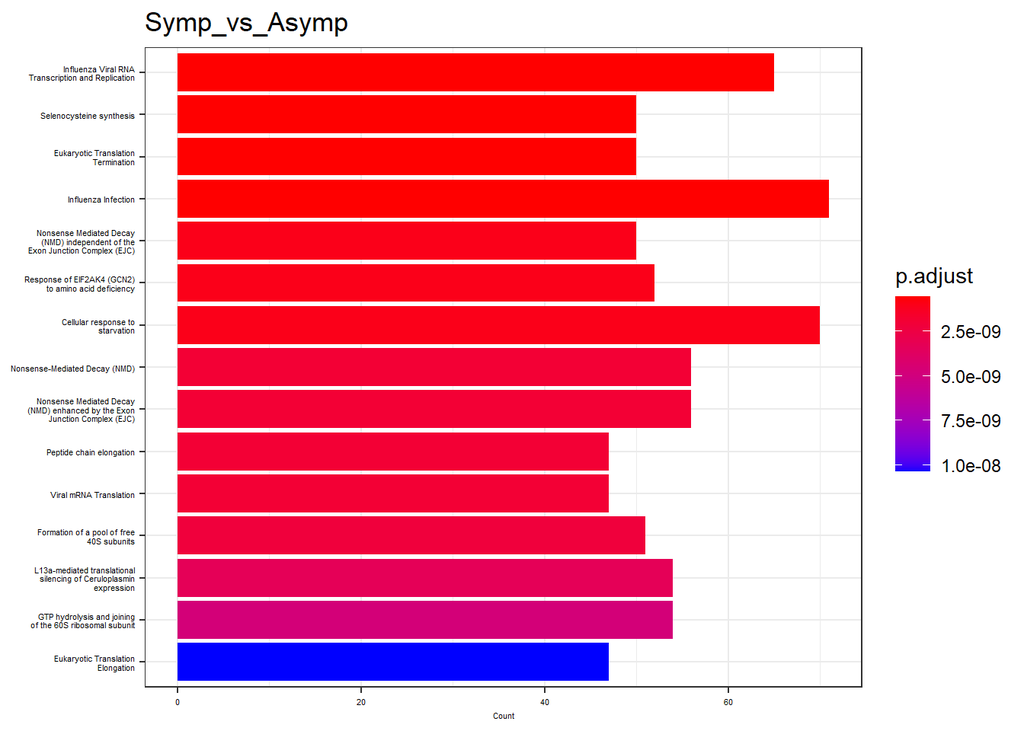

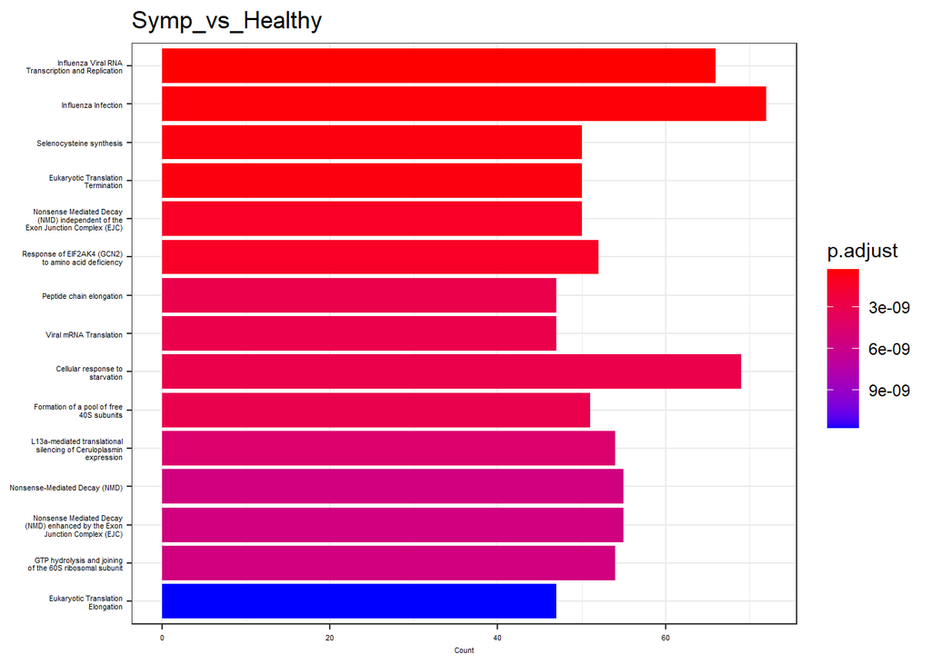

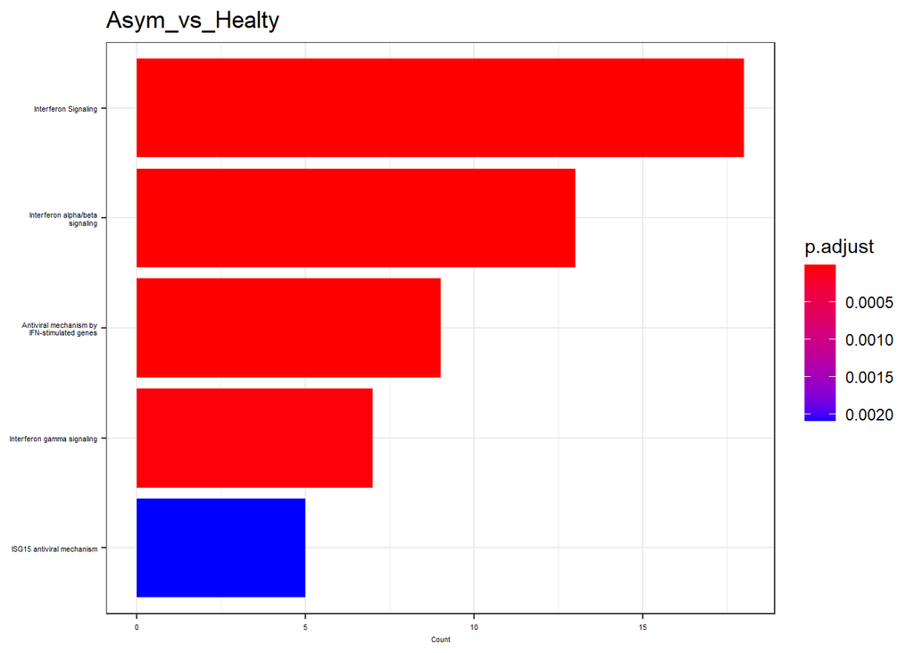

```r
list_of_data <- list_of_selected[1:3]
comparisons <- names(list_of_data)
universe <- mapped_genes

for (i in 1:length(list_of_data)){
  genes_IN <- list_of_data[[i]]
  comparison <- comparisons[i]
  enrich.result <- enrichPathway(gene = genes_IN,
                                 pvalueCutoff = 0.05,
                                 pAdjustMethod = "BH",
                                 organism = "human",
                                 universe = universe)
  if (length(rownames(enrich.result@result))!=0){
    write.csv2(as.data.frame(enrich.result),
               file = paste0("./resultats/","ReactomePA.results", comparison,".csv"),
               row.names = F)
    print(barplot(enrich.result, showCategory = 15, font.size = 4,
                  title = paste0(comparison)))
  }
}
```